# Example solutions for In-Class Workshops

Maria Kjellsson, Uppsala University

2020-11-19

Abstract

Below are solutions to the exercises in the In-Class Workshops (ICW). Please view these as examples of solutions, not THE answers. There are as many solutions to a problem as there are programmers.

# Basic R

In this ICW section, we go through the basic aspects of R and programming in R.

## 1) Execution of commands

There are several ways to execute commands in R studio.

The easiest way is to type the command directly in the console (Remember which "box" in R studio this was?) and press **`enter`**. This will execute the command.

This is an excellent way of testing how to write the commands for a certain operation. The main drawback with this way is that the commands are not saved anywhere.

Use the command-line to execute the following code:

```r
1 + 1
test <- 1 + 1
test
## [1] 2
## [1] 2
```

The operations are visible in your history (Remember where the history is found in R studio?). The object `test` is saved in your environment (Remember which "box" in R studio the environment is?).

Close down R studio, *do not* save workspace to ~/.RData and relaunch R studio. What happend with the object `test` and your history?

*The history and the environment are empty.*

Do the same command again:

```r
test <- 1 + 1
```

Close down R studio, this time sace the workspace to ~/.RData and relaunch R studio again. Can you find the oject called test in your environment and history?

*Yes, this time it's saved. It's is regenerated from .RData when you open R studio.*

If you are working on a project where multiple R-commands are required, we recommend that you create a workflow, i.e. save all commands that you want to keep in an R-script.

Go to File, choose New File, and then R Script to create an R-script. A new file is opened in the source editor. Save the R-script to your computer using a suitable name.

In the script you save commands that performs the required actions for a particular task. However, save only actions that work and produce the intended results, not all your intermediate attempts.

Execution of code in an R-script could be done line-by-line or by selection by highlighting a section of your code.

The action of execution is done by either using the Run button in the right corner of the source editor or the short-command ctrl-enter (or cmd-enter for Mac).

In the tutorial on basic commands by Mike, he used the source editor with short-commands and executed either line by line or subsets.

Open the R-script **R-script.R**. Run the commands in the R-script line-by-line. Which objects are created? What appears in the console?

**The objects a, b, c and d were created and you see the output below.**

Mark the whole content of the R-script and execute. Is there any difference from running line-by-line?

```r
a <- c(0, 5, 23, 30)
b <- 1
c <- seq(1, 7, by = 2)
d <- 1:4

a + b + c + d
a * c

print(a * c)
## [1]  3 11 32 42
## [1]   0  15 115 210
## [1]   0  15 115 210
```

You can also source an R-script, which means the entire script is executed from start to end. The action of sourcing is done by using the Source button in the right corner of the source editor.

Source the R-script you previously executed line-by-line and by selection. Is there any difference from running the script as you did above?

## 2) Work directory

The work directory the directory where R is executing the commands. The only files and directories visible for R are those visible from the directory which is set as the work directory. In this section, you will work with work directories.

In the console, type the following command:

```r
getwd()
```

What is the output? What do you think the function `getwd()` does?

*It returns the name of the folder that is the current workdirectory**

In the console, type the following commands, place the cursor between the parenthesis/the quotes and use the **tab-key** for autocompletion. What is the difference between the two?

*In the first, it types `dir =` which is an argument to the function. In the latter, it gives you the folders that you hace below the folder that is your working directory.*

```r
setwd()
setwd("")
```

What do you think the function `setwd()` does?

*`setwd()` is used to set the workdirectory to something else than what it currently is*

Now, in the console, type the following command, place the cursor between the quotes and use **tab** for autocompletion. (The function `read.table` imports data into R from a file.)

```r
read.table("")
```

Note that the options are difference between placing the cursor between the quotes of `setwd("")` and `read.table("")`. Why do you think this is?

*With `setwd("")` you see the folders and with `read.table("")` you see the files. It's because `setwd()` is expecting the input to be a folder while `read.table() expects the input to be a file. Clear, ehe?*

In the console, type the following command:

```r
setwd("..")
getwd()
```

You do you think the dots (i.e. `../`) in `setwd()` do?

*`../` is used to indicate that you want to access a folder that is above the current folder*

Set your working directory to the directory where you have the downloaded files from Studium.

## 3) Help and tutorials in R

It is crucial to be able to get help with R. I assure you, you will not remember all function names and their arguments...

There are many different ways to get help for R, both internal and online help. Apart from all help functions and code-snippets available for R online, you can also find tutorials for self-education. One such platform is Quick-R, on *http://statmethods.net*.

In this section, you will work with various ways of getting help in R.

Try the two following commands.

```r
?read.table()
??read.table()
```

They do not give the same output. What do you think is the differences between these two help functions?

*The difference is that with `?read.table` you get the specific help for the function with its arguments, while `??read.table` is a more general help searching the help for the word read.table*

Try the following commands:

```r
?read.table
help(read.table)
```

What are the differences between these two help functions?

*No difference. It gives the same output, the help for the function*

Another way of gettin help is to use the menu **Help** at the top. Apart from searching specific words or functions, you will also find cheatsheets here. Orient yourself in these.

Select the top-menu **Help** and then **R help**. Yet another way to get help.

Go to *http://statmethods.net/about/learningcurve.html*. Read the text at this page.

Enter the free interactive course in the middle of the page, by selection 'this free R-tutorial by DataCamp'. Create an account and follow the course to the *What's the data type?*

As a last exercise in this section, read the help section for the function `read.table()` and figure out how to import the dataset named `data_for_ICW.csv` into R.

## 4) Assigning and indexing objects

To be able to work with the vectors, datasets etc., you need to assign objects containing your vectors, datasets etc. To access elements in your objects you need to be able to index an object. In this section, you will work with both assigning objects (which you've already done during the online Intro to R) and indexing.

Create an object called `int1` containing integers from 5 to 15 with steps of 1.

How many different ways can you do this?

```r
int1 <- c(5, 6, 7, 8, 9, 10, 11, 12, 13, 14, 15) # not preferred with long vectors
int1
int1 <- seq(from = 5, to = 15, by = 1)
int1
int1 <- seq(from = 5, to = 15, length.out = 11)
int1
int1 <- 5:15
int1

#Note: Although I execute 4 different codes, I will only create one int1,
#since I overwrite the object in each command.
##  [1]  5  6  7  8  9 10 11 12 13 14 15
##  [1]  5  6  7  8  9 10 11 12 13 14 15
##  [1]  5  6  7  8  9 10 11 12 13 14 15
##  [1]  5  6  7  8  9 10 11 12 13 14 15
```

What is the class of `int1`?

```r
class(int1)
## [1] "integer"
```

*The class is either `integer` or `numeric` depending on which of the above functions you use to create the object*

Take the sum of all even elements of the object `int1` (i.e. the elements containing 6, 8, 10, 12 and 14) and substract the sum of all odd elements of the object `int1` (i.e. the elements containing 5, 7, 9, 11, 13 and 15). How many ways can you do this?

```r
odd <- int1[c(2, 4, 6, 8, 10)] #extracting with positions the odd values
even <- int1[c(1, 3, 5, 7, 9, 11)] #extracting with positions the even values
sum(odd) - sum(even) # taking the sum of each before subtracting

# creating a vector with the positions of odd elements
odd_pos <- seq(2, length(int1), by = 2)
#creating a vector with the positions of even elements
even_pos <- seq(1, length(int1), by = 2)
sum(int1[odd_pos]) - sum(int1[even_pos])
## [1] -10
## [1] -10
```

*Same answer independent of how you do it :)*

Use the function `read.table()` to import the dataset named `data_for_ICW.csv` into R and assign it to an object called `data`.

```r
data <- read.table(file = "data_for_ICW.csv", header = TRUE, sep = ",")
```

Use the following command to look at your object `data`:

```r
str(data)
## 'data.frame':    2183 obs. of  34 variables:
##  $ ID   : int  1 1 1 1 1 1 1 1 1 1 ...
##  $ DV   : num  NA NA NA 0 0.511 ...
##  $ TIME : num  0 36 144 144 144 ...
##  $ GEN  : int  1 1 1 1 1 1 1 1 1 1 ...
##  $ WT   : num  96 96 96 96 96 96 96 96 96 96 ...
##  $ HT   : num  1.85 1.85 1.85 1.85 1.85 1.85 1.85 1.85 1.85 1.85 ...
##  $ AGE  : int  24 24 24 24 24 24 24 24 24 24 ...
##  $ CREA : int  80 80 80 80 80 80 80 80 80 80 ...
##  $ BSA  : num  2.2 2.2 2.2 2.2 2.2 2.2 2.2 2.2 2.2 2.2 ...
##  $ GRF  : int  103 103 103 103 103 103 103 103 103 103 ...
##  $ ALAT : int  32 32 32 32 32 32 32 32 32 32 ...
##  $ HBA1C: int  32 32 32 32 32 32 32 32 32 32 ...
##  $ AMT  : int  500 1000 1000 0 0 0 0 0 0 0 ...
##  $ EVID : int  1 1 1 2 0 0 0 0 0 0 ...
##  $ GT1  : int  0 0 0 0 0 0 0 0 0 0 ...
##  $ GT2  : int  1 1 1 1 1 1 1 1 1 1 ...
##  $ GT3  : int  1 1 1 1 1 1 1 1 1 1 ...
##  $ GT4  : int  0 0 0 0 0 0 0 0 0 0 ...
##  $ GT5  : int  2 2 2 2 2 2 2 2 2 2 ...
##  $ GT7  : int  0 0 0 0 0 0 0 0 0 0 ...
##  $ GT6  : int  0 0 0 0 0 0 0 0 0 0 ...
##  $ II   : int  12 12 0 0 0 0 0 0 0 0 ...
##  $ CMT  : int  1 1 1 4 2 2 2 2 2 2 ...
##  $ MDV  : int  1 1 1 1 0 0 0 0 0 0 ...
##  $ TYPE : num  0 0 0 0.5 1 1 1 1 1 1 ...
##  $ TRT  : int  1 1 1 1 1 1 1 1 1 1 ...
##  $ TRT2 : int  1 1 1 1 1 1 1 1 1 1 ...
##  $ R1   : int  NA NA NA 2 NA NA NA NA NA NA ...
##  $ R2   : int  NA NA NA 0 NA NA NA NA NA NA ...
##  $ TEMP1: int  1 1 1 0 0 0 0 0 0 0 ...
##  $ TEMP2: int  0 1 1 0 0 0 0 0 0 0 ...
##  $ TEMP3: int  0 0 1 0 0 0 0 0 0 0 ...
##  $ TEMP4: int  NA NA NA 1 1 1 1 1 1 1 ...
##  $ ADDL : int  2 8 0 NA NA NA NA NA NA NA ...
```

If your object `data` have 34 columns (`variables`) and 2183 rows (`obs`), you imported the project correctly. What is the name of the first `variable`?

*The first variable is ID*

## 5) Class of object

The class of an object determines how many functions work. In this section, we will focus on classes of objects.

Create five vectors with the following commands:

```r
int  <- as.integer(1:6)
num  <- as.numeric(7:13)
char <- paste0("hello", int)
fac  <- factor(rep(c("hello","bye"), 3))
log  <- rep(c(TRUE,FALSE), 3)
```

Use the function `summary()` on each of these five objects. Compare the output.

```r
summary(int)
```

```
##    Min. 1st Qu.  Median    Mean 3rd Qu.    Max.
##    1.00    2.25    3.50    3.50    4.75    6.00
```

```r
summary(num)
```

```
##    Min. 1st Qu.  Median    Mean 3rd Qu.    Max.
##     7.0     8.5    10.0    10.0    11.5    13.0
```

```r
summary(char)
```

```
##    Length     Class      Mode
##         6 character character
```

```r
summary(fac)
```

```
##   bye hello
##     3     3
```

```r
summary(log)
```

```
##    Mode   FALSE    TRUE
## logical       3       3
```

Use the function `class()` to investigate each of the classes of the vectors.

```r
class(int)
```

```
## [1] "integer"
```

```r
class(num)
```

```
## [1] "numeric"
```

```r
class(char)
```

```
## [1] "character"
```

```r
class(fac)
```

```
## [1] "factor"
```

```r
class(log)
```

```
## [1] "logical"
```

Add the vectors together two and two, see the example below.

```r
fac_log  <- c(fac,log)
```

Investigate the class of each of these combined vectors. Can you identify how the combinations determines the class of the new, combined object?

```r
class(c(int, num))
```

```
## [1] "numeric"
```

```r
class(c(int, char))
```

```
## [1] "character"
```

```r
class(c(int, fac))
```

```
## [1] "integer"
```

```r
class(c(int, log))
```

```
## [1] "integer"
```

```r
class(c(num, char))
```

```
## [1] "character"
```

```r
class(c(num, fac))
```

```
## [1] "numeric"
```

```r
class(c(num, log))
```

```
## [1] "numeric"
```

```r
class(c(char, fac))
```

```
## [1] "character"
```

```r
class(c(char, log))
```

```
## [1] "character"
```

```r
class(c(fac, log))
```

```
## [1] "integer"
```

*Anything that is combined with a character object, will be a `character`. Combining factors, logicals or integers will give `integer`. Combining numeric with integer, factor or logical will create `numeric`.*

Add all vectors together (see below). Can you guess in advance what class the vector `new` will be?

```r
new  <- c(fac, log, char, num, int)
class(new)
## [1] "character"
```

Create a numerical vector, containing 1, 1, 2, 2, 3, 3. Change the class to factor. Tip: Use the function factor. How many levels are created?

```r
num <- rep(c(1, 2, 3), each = 2)
fac <- as.factor(num)
fac
## [1] 1 1 2 2 3 3
## Levels: 1 2 3
```

*Three levels are created: 1, 2 and 3.*

# Reproducible Research

An important part of research is working in a reproducible manner. One tool to aid reproducibility is R-markdown; a method to seamlessly integrate the analysis with the report writing. Reproducibility regarding wet-lab results is one thing, but imbedding the data management, the graphical exploration and the statistical calculations to the text describing the methods, interpreting the results and discussing the conclusions is 'easy' through R-markdown and promotes reproducibility.

In this module, which is optional, you get test using R-markdown. The Rmd-documents (i.e. R-markdown document) contains 3 parts: 1) the YAML, 2) the chunks and 3) the text, each section below focuses on one of the three parts. The R-package to use is called "Knitr", which you first have to install.

```r
install.packages("knitr")
```

Then choose **File**, **New File**, and **R Markdown** and fill in the wizard which is opened when you click on **R Markdown**. Save the document with an appropriate name (remember good coding practice?) using the suffix .Rmd.

## 1) YAML title

The top part of an R-markdown document is the YAML with the information about how the document should look. In this section you will try a few options.

Create an R-markdown document (as described above) and knit it (i.e. click on the Knit-button). Go to http://rmarkdown.rstudio.com/html_document_format.html and read about how to adapt the YAML for rendering an HTML-document.

Change in you YAML to include a table of content. What happens when you specify `toc_float`?

Try a few themes available. listed on the [page](http://rmarkdown.rstudio.com/html_document_format.html). Which theme do you prefer?

*I like the theme Journal. It's clean and a bit strict.*

Adapt the YAML as you feel is appealing to you.

## 2) Code Chunk

All operations related to code are performed in so called [chunks](https://rmarkdown.rstudio.com/lesson-3.html). How R handles the code inside the chunk is specified by various options.

A chunk is always initialised by ``` followed by an opening { and then specifying which language should be used in interpreting the chunk (e.g. r, python). It is optional, but recommended, to provide a name of the chunk, which you do after the language and if you do not provide any arguments for the chunk, you use } to end the initialisation of the chunk. The whole chunk is then closed with ``` , see the example below.

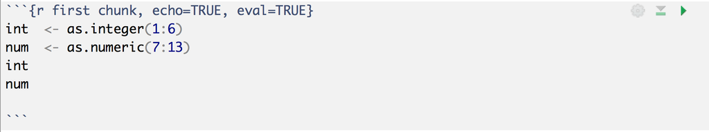

*Chunk 1*

Knit your document.

Now change echo to `FALSE` and knit again. How is the document different?

*The echo=TRUE sets if the code should be shown in the document or not (set to FALSE)*

Change echo back to `TRUE` and change eval to `FALSE`. How is the document different?

*The eval=TRUE sets if the chunk should be evaluated or not (set to FALSE)*

Change eval back to `TRUE` and the option `results = "hold"`. What happens?

*The option results="hold" will not print each output one by one, but will hold all results of a chunk and then print all the output in one go.*

Create a chunk as shown below. When you knit the document you get an error. Why?

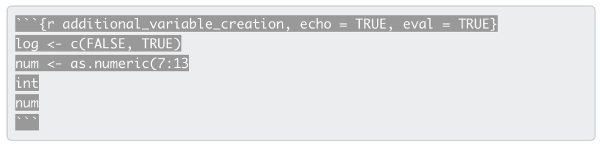

*Chunk 2*

*There was a missing closing parenthesis. The error messages are however not always that easy to interpret. If you have names of your chunks you will at least know in which chunk the error is.*

## 3) Text

The last oart of the R-mardkonw file is the text and some format options are available for text.

Add a new chunk, as the chunk below:

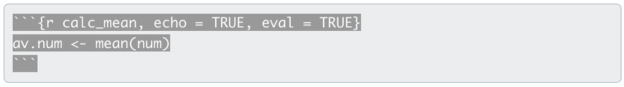

*Chunk 3*

Underneath (i.e. outside) the chunk type the following: **The average of the num object is `av.num`.** Knit the document. What happens?

*The output of the above text is: The average of the num object is* `av.num`. *Changing the format to look more like console-text*

Now, insert an `r` between the symbol av.num: **The average of the num object is `av.num`.** Knit the document. How is the output different?

You can create bullet of numered lists in your Rmd-document. Copy the following into your document as text;

* With various symbols, it is **possible** to format the text *quite* much.

* You can even make ~~lists~~.

The output is as follow:

- With various symbols, it is **possible** to format the text *quite* much.
- You can even make lists.

*This document was created using R markdown.*

# Data Management

I would like to start this In-Class workshop with a tip: Test, test, test!

You will only be a proficient R-programmer if you dare to try different combinations of functions, different arguments etc. Have fun! It is next to impossible to break the system.

We have given you a few exercises below, but we encourage you to test more options and combinations to fully understand how functions work and how to do data management in R.

## 1) Import/export

n R, the data management is not actually performed in the data set you have on your computer unlike for example Excel. The data management is performed on an object, created from the data set. Thus, you first need to create an object, containing the data, from the data set. When you are done with your data management, you need to export the object as a file on your computer. This way of working is good from a reproducibility view, as the original data is not changed (unless you overwrite it when exporting your 'managed data'). The data source for the object could be almost any format, e.g. csv, txt, xlsx, sas7bdat.

### 1.1) Import

In previous ICW, you imported data from a file (data_for_ICW.csv) as the object data using the function `read.table()`. When importing data from a data set on your computer as an R-object, it is wise to first have a look at data, for example using a simple text editor. Things to look for are:

1. Does the data have a heading or not?
- Should this heading be used or skipped?
2. Does the file start with blank rows that should be ignored?
- Or other rows that we do not wish to import?
3. What symbol is used as separator between columns?
- Usually , or ; for file with the extension csv
- Usually white space for files with extension txt
4. What symbol is used to indicate decimals?
5. What symbol is used to indicate missing values (or NA)?
6. Is there a mixture of numbers and characters in one column?
7. Do all columns have the same length?

With large datasets, this is more difficult to 'look' at the data, but it's still important to keep these 7 bullets in mind. If an object is not created as was expected, it will most likely be due to not considering 1 of the 7 bullets in the import function.

Look at the different arguments for the function `read.table()`. Idenfity how to set the argument for the following if:

1. Your data have a header, but you do not wish to use it as names of your variables.
2. The first row is blank, followed by two rows with notes, you do not wish to import and then a header, which you wish to use as names for your variables.
3. Your variables are separated by ; the decimal sign is , and missing values are indicated with -

Look at the data `example_data.csv`. What options do you need to consider? Import `example_data.csv` as an object called `wide_data`.

```r
wide_data <- read.table(file = "example_data.csv",
                        header = T, skip = 5,
                        na.strings = ".", sep = ",")
```

Use the function `str()`with your object `wide_data, how many variables and observations does it contain?

```r
str(wide_data)
## 'data.frame':    10 obs. of  11 variables:
##  $ TIME   : num  0 0.5 1 1.5 2 4 6 8 12 24
##  $ ID.1221: int  1066 992 1009 NA 3604 2700 2065 2426 1620 982
##  $ ID.1222: int  2537 2331 3137 5733 5850 4816 4162 3348 2469 2051
##  $ ID.1223: int  1758 1730 4135 5006 NA 4954 3658 2695 2212 1714
##  $ ID.1224: int  1127 1011 1158 1173 1478 3808 4036 3106 2511 1124
##  $ ID.1225: int  1403 1369 NA 1650 2473 3863 4612 3770 2328 1187
##  $ ID.1226: int  1759 1695 3838 4116 4602 4469 3430 2925 2101 840
##  $ ID.1227: int  NA 1589 1529 1329 1659 5558 4372 3677 2858 1440
##  $ ID.1228: num  832 734 926 1165 2305 ...
##  $ ID.1229: int  1152 1318 3684 6159 5748 3427 2938 2549 1842 811
##  $ ID.1230: int  1473 1398 2024 2154 2826 3004 3798 2854 2126 1380
```

*It contains 11 variables and 10 observerations.*

### 1.2) Export

The object with the 'managed data' can be exported using the function `write.table()`. Look at the arguments for `write.table()`. The arguments resemble those of `read.table()`, but this time they determine how the object should be exported.

Change the name of the first variable (i.e. column in a data.frame) of the object `wide_data` from `TIME` to `Time` using the following command:

```r
names(wide_data)[1] <- "Time"
```

Use the function `write.table()` to export the object wide_data to a file named **exported_testdata.txt**, use ; as delimiter and , as decimal symbol and - as missing symbol. Can you find the file when you browse your computer's folders and is the name of the first variable Time instead of TIME?

```r
write.table(x = wide_data, file = "exported_testdata.txt",
            sep = ";", dec = ",", na = "-", row.names = FALSE)
```

*The file will be created in your work directory.*

## 2) Working with selected subsets of an object

### 2.1) Indexing

To transform specific variable or observation (i.e. row) of a `data.frame`, it's important to know how to index. You can index by position (i.e. by number), or by name of the variable.

From object `wide_data`, print in the console the value in the 3rd variable and the 1st observation. It should be 2537. If you get the value=1, you've switched observation and variable number.

```r
wide_data[1, 3]
## [1] 2537
```

From object wide_data, print in the console all values of the 3rd variable, i.e. the variable called `ID.1222`. There are three ways to do this and the output is identical for two of the alternatives. Try the commands below:

```r
wide_data[, 3]
```

```
##  [1] 2537 2331 3137 5733 5850 4816 4162 3348 2469 2051
```

```r
wide_data$ID.1222
```

```
##  [1] 2537 2331 3137 5733 5850 4816 4162 3348 2469 2051
```

```r
wide_data["ID.1222"]
```

| ID.1222 |
| --- |
| 2537 |
| 2331 |
| 3137 |
| 5733 |
| 5850 |
| 4816 |
| 4162 |
| 3348 |
| 2469 |
| 2051 |

*The last option returns a dataframe while the other options returns vectors*

### 2.2) Subsetting

|  | Time | ID.1221 | ID.1222 | ID.1223 | ID.1224 | ID.1225 | ID.1226 | ID.1227 | ID.1228 | ID.1229 | ID.1230 |
| --- | --- | --- | --- | --- | --- | --- | --- | --- | --- | --- | --- |
| 5 | 2 | 3604 | 5850 | NA | 1478 | 2473 | 4602 | 1659 | 2305 | 5748 | 2826 |

|  | Time | ID.1221 | ID.1222 | ID.1223 | ID.1224 | ID.1225 | ID.1226 | ID.1227 | ID.1228 | ID.1229 | ID.1230 |
| --- | --- | --- | --- | --- | --- | --- | --- | --- | --- | --- | --- |
| 5 | 2 | 3604 | 5850 | NA | 1478 | 2473 | 4602 | 1659 | 2305 | 5748 | 2826 |

|  | Time | ID.1221 | ID.1222 | ID.1223 | ID.1224 | ID.1225 | ID.1226 | ID.1227 | ID.1228 | ID.1229 | ID.1230 |
| --- | --- | --- | --- | --- | --- | --- | --- | --- | --- | --- | --- |
| 5 | 2 | 3604 | 5850 | NA | 1478 | 2473 | 4602 | 1659 | 2305 | 5748 | 2826 |

*No there is no difference. In all three alternatives a dataframe is the output*

Create a vector called values, containing values between 700 and 800, with steps of 1. There are several ways to do this.

Use the function `match()` to compare the claues in the vector created in the precious step and the values in the variable called `ID.1228` in `wide_data` (see below). What is the output indicating?

Note: Make sure that your variable ID.1228 is numeric.

```r
value <- seq(700, 800, by = 1)
#value <- seq(700, 800, length.out = 101)
#value <- 701:800
match(value, wide_data$ID.1228, nomatch = 0)
##   [1]  0 10  0  0  0  0  0  0  0  0  0  0  0  0  0  0  0  0  0  0  0  0  0  0  0
##  [26]  0  0  0  0  0  0  0  0  0  0  0  0  0  0  0  0  0  0  0  0  0  0  0  0  0
##  [51]  0  0  0  0  0  0  0  0  0  0  0  0  0  0  0  0  0  0  0  0  0  0  0  0  0
##  [76]  0  0  0  0  0  0  0  0  0  0  0  0  0  0  0  0  0  0  0  0  0  0  0  0  0
## [101]  0
```

Now, put the above expression as index of the variable called ID.1228 of wide_data (see below). What is the output now?

```r
wide_data$ID.1228[match(value, wide_data$ID.1228, nomatch = 0)]
## [1] 701
```

The variable called ID.1228 contains two values between 700 and 800. Why was only one value indicated (i.e. 701)?

*This code only matches the integer values in* `value` *to the values in* `wide_data$ID.1228`*. Hence, 733.5 is not indicated*

How should you have performed the task if you wanted ALL values for variable ID.1228 between 700 and 800? Compare the three following commands. Differences? Similarities?

```r
wide_data[wide_data$ID.1228 >= 700 & wide_data$ID.1228 <= 800, 9]
wide_data$ID.1228[wide_data$ID.1228 >= 700 & wide_data$ID.1228 <= 800]
subset(wide_data, ID.1228 >= 700 & ID.1228 <= 800, select = ID.1228)
## [1] 733.5 701.0
## [1] 733.5 701.0
```

|  | ID.1228 |
| --- | --- |
| 2 | 733.5 |
| 10 | 701.0 |

*Again, the subset returns a dataframe while the other two options returns vectors. Note also the notation with subset where you don't have to specify* `wide_data` *before the names of the variables. This is a special feature of this function*

If you have a `data.frame that is long format (i.e. all individuals data for all time points underneath each other), you can use the following command to extract only the first record for each individual:

```r
first <- data[!duplicated(data$ID), ]
```

This should be interpreted: in the object `long_data`, do not take duplicated observations where the value in the variable called `ID` are the same; include all variable. To better understand what it does we will break it down.

Create an object called `long_data` from `data_for_ICW.csv`, setting the separator to , and header to TRUE.

```r
long_data <- read.csv(file = "data_for_ICW.csv",
                      sep = ",", header = TRUE)
```

Use the function `duplicated()` on the variable `ID` of the object `long_data`. The function returns TRUE if it is a duplicate and FALSE if it is the first of its kind.

```r
duplicated(long_data$ID)
```

```r
head(duplicated(long_data$ID))
## [1] FALSE  TRUE  TRUE  TRUE  TRUE  TRUE
```

*The vector is longer than what is displayed here*

Use the ! sign in front of expression: duplicated(long_data$ID). How did the output change?

```r
!duplicated(long_data$ID)
```

```
## [1]  TRUE FALSE FALSE FALSE FALSE FALSE
```

*The result is that TRUE becomes FALSE and vice versa. The vector is longer than what is displayed here*

Indexing with TRUE and FALSE will result in the positions indicated TRUE being extract while those indicated with FALSE are not.

Use the expression: !duplicated(long_data$ID) as an index to the object long_data$ID. What is the output?

```r
long_data$ID[!duplicated(long_data$ID)]
```

```
## [1] 1 2 3 4 5 6
```

*The vector is long than what is displayed here*

If you wish to extract all variables of the object long_data, how would you indicate this?

*If you do not specify that you're just picking* `ID` *in long data but instead do the following, you'll get all variables. Note that the data.frame is larger than what is displayed.*

```r
long_data[!duplicated(long_data$ID), ]
```

|  | ID | DV | TIME | GEN | WT | HT | AGE | CREA | BSA | GRF | ALAT | HBA1C | AMT | EVID | GT1 | GT2 | GT3 | GT4 | GT5 | GT7 | GT6 | II | CMT | MDV | TYPE | TRT | TRT2 | R1 | R2 | … |
| --- | --- | --- | --- | --- | --- | --- | --- | --- | --- | --- | --- | --- | --- | --- | --- | --- | --- | --- | --- | --- | --- | --- | --- | --- | --- | --- | --- | --- | --- | --- |
| 1 | 1 | NA | 0 | 1 | 96.0 | 1.85 | 24 | 80 | 2.20 | 103 | 32 | 32 | 500 | 1 | 0 | 1 | 1 | 0 | 2 | 0 | 0 | 12 | 1 | 1 | 0 | 1 | 1 | NA | NA | … |
| 24 | 2 | NA | 0 | 1 | 71.0 | 1.77 | 24 | 85 | 1.87 | 96 | 37 | 33 | 500 | 1 | 0 | 1 | 1 | 0 | 1 | 0 | 0 | 12 | 1 | 1 | 0 | 1 | 1 | NA | NA | … |
| 47 | 3 | NA | 0 | 1 | 71.0 | 1.76 | 26 | 78 | 1.87 | 104 | 20 | 33 | 500 | 1 | 2 | 1 | 0 | 0 | 1 | 0 | 0 | 12 | 1 | 1 | 0 | 1 | 1 | NA | NA | … |
| 70 | 4 | NA | 0 | 1 | 87.5 | 1.90 | 30 | 79 | 2.16 | 100 | 25 | 33 | 500 | 1 | 1 | 1 | 2 | 0 | 0 | 0 | 0 | 12 | 1 | 1 | 0 | 1 | 1 | NA | NA | … |
| 93 | 5 | NA | 0 | 1 | 73.0 | 1.82 | 28 | 101 | 1.94 | 76 | 58 | 32 | 500 | 1 | 1 | 1 | 2 | 1 | 1 | 0 | 0 | 12 | 1 | 1 | 0 | 1 | 1 | NA | NA | … |
| 116 | 6 | NA | 0 | 1 | 68.0 | 1.76 | 24 | 81 | 1.83 | 102 | 30 | 32 | 500 | 1 | 1 | 0 | 1 | 1 | 1 | 0 | 0 | 12 | 1 | 1 | 0 | 1 | 1 | NA | NA | … |

How would you write an expression that keeps the first unique value of TIME and outputs only the ID variable?

```r
long_data$ID[!duplicated(long_data$TIME)]
```

```
## [1] 1 1 1 1 1 1
```

*The vector is longer than what is displyed here*

### 2.3) Create new variables in objects

Creating variables in data.frame objects is easy. By indexing the object as if the varaible was already in the object, you create a new variable (see example below).

```r
data$Some_New_Variable <- "Fil with suitable content"
```

This expression will create a variable in data called `Some_New_Variable` and fill the whole column with "Fill with suitable content". If you wish to fill the variable with different values, the lengths of the "filling" needs to be that of the variables in data.

Continue to use the object `long_data`. Create a new variable in the object `long_data` and call it `TEST`.Fill it with `NA`. Use the function `str()` to look at the content of the object. What is the data type of the variable `TEST`?

```r
long_data$TEST <- NA
str(long_data)
## 'data.frame':    2183 obs. of  35 variables:
##  $ ID   : int  1 1 1 1 1 1 1 1 1 1 ...
##  $ DV   : num  NA NA NA 0 0.511 ...
##  $ TIME : num  0 36 144 144 144 ...
##  $ GEN  : int  1 1 1 1 1 1 1 1 1 1 ...
##  $ WT   : num  96 96 96 96 96 96 96 96 96 96 ...
##  $ HT   : num  1.85 1.85 1.85 1.85 1.85 1.85 1.85 1.85 1.85 1.85 ...
##  $ AGE  : int  24 24 24 24 24 24 24 24 24 24 ...
##  $ CREA : int  80 80 80 80 80 80 80 80 80 80 ...
##  $ BSA  : num  2.2 2.2 2.2 2.2 2.2 2.2 2.2 2.2 2.2 2.2 ...
##  $ GRF  : int  103 103 103 103 103 103 103 103 103 103 ...
##  $ ALAT : int  32 32 32 32 32 32 32 32 32 32 ...
##  $ HBA1C: int  32 32 32 32 32 32 32 32 32 32 ...
##  $ AMT  : int  500 1000 1000 0 0 0 0 0 0 0 ...
##  $ EVID : int  1 1 1 2 0 0 0 0 0 0 ...
##  $ GT1  : int  0 0 0 0 0 0 0 0 0 0 ...
##  $ GT2  : int  1 1 1 1 1 1 1 1 1 1 ...
##  $ GT3  : int  1 1 1 1 1 1 1 1 1 1 ...
##  $ GT4  : int  0 0 0 0 0 0 0 0 0 0 ...
##  $ GT5  : int  2 2 2 2 2 2 2 2 2 2 ...
##  $ GT7  : int  0 0 0 0 0 0 0 0 0 0 ...
##  $ GT6  : int  0 0 0 0 0 0 0 0 0 0 ...
##  $ II   : int  12 12 0 0 0 0 0 0 0 0 ...
##  $ CMT  : int  1 1 1 4 2 2 2 2 2 2 ...
##  $ MDV  : int  1 1 1 1 0 0 0 0 0 0 ...
##  $ TYPE : num  0 0 0 0.5 1 1 1 1 1 1 ...
##  $ TRT  : int  1 1 1 1 1 1 1 1 1 1 ...
##  $ TRT2 : int  1 1 1 1 1 1 1 1 1 1 ...
##  $ R1   : int  NA NA NA 2 NA NA NA NA NA NA ...
##  $ R2   : int  NA NA NA 0 NA NA NA NA NA NA ...
##  $ TEMP1: int  1 1 1 0 0 0 0 0 0 0 ...
##  $ TEMP2: int  0 1 1 0 0 0 0 0 0 0 ...
##  $ TEMP3: int  0 0 1 0 0 0 0 0 0 0 ...
##  $ TEMP4: int  NA NA NA 1 1 1 1 1 1 1 ...
##  $ ADDL : int  2 8 0 NA NA NA NA NA NA NA ...
##  $ TEST : logi  NA NA NA NA NA NA ...
```

*The newly created variable is a logical*

Attempt to overwrite the variable TEST with the vector 1:3. What is the error message?

```r
long_data$TEST <- 1:3
```

*It will say* `Error in \$<-.data.frame(*tmp*, TEST, value = 1:3) : replacement has 3 rows, data has 2183`

Now attempt to overwrite the variable TEST with the vector 1:length(long_data$ID). What happens? Why does this work but not the previous (i.e. 1:3)?

```r
long_data$TEST <- 1:length(long_data$ID)
```

*This works since the length of the varibles in long_data are the same as what is added in the new variable TEST.*

Use the function `paste()` to overwrite the content of variable TEST with the content in variables GEN and WT, pasted together by _.

```r
long_data$TEST <- paste(long_data$GEN, long_data$WT, sep = "_")
# if you use the following:
#long_data$TEST <- paste("GEN", "WT", sep = "_")
#you will paste the words GEN and WT together, not the content
```

Compare the functions paste() to paste0(). `paste0()` * is a version of * `paste()` * where the argument sep= has been set to nothing (i.e. sep = ("")*

Split the new variable TEST, using the function `strsplit()` and split on '_'. Put the output from the expression into a new object called splitTEST. What is the data type of splitTEST? Tip: try `str()`

```r
splitTEST <- strsplit(long_data$TEST, split = "_")
str(splitTEST)
## List of 2183
##  $ : chr [1:2] "1" "96"
##  $ : chr [1:2] "1" "96"
##  $ : chr [1:2] "1" "96"
##  $ : chr [1:2] "1" "96"
##  $ : chr [1:2] "1" "96"
##  $ : chr [1:2] "1" "96"
##  $ : chr [1:2] "1" "96"
##  $ : chr [1:2] "1" "96"
##  $ : chr [1:2] "1" "96"
##  $ : chr [1:2] "1" "96"
##  $ : chr [1:2] "1" "96"
##  $ : chr [1:2] "1" "96"
##  $ : chr [1:2] "1" "96"
##  $ : chr [1:2] "1" "96"
##  $ : chr [1:2] "1" "96"
##  $ : chr [1:2] "1" "96"
##  $ : chr [1:2] "1" "96"
##  $ : chr [1:2] "1" "96"
##  $ : chr [1:2] "1" "96"
##  $ : chr [1:2] "1" "96"
##  $ : chr [1:2] "1" "96"
##  $ : chr [1:2] "1" "96"
##  $ : chr [1:2] "1" "96"
##  $ : chr [1:2] "1" "71"
##  $ : chr [1:2] "1" "71"
##  $ : chr [1:2] "1" "71"
##  $ : chr [1:2] "1" "71"
##  $ : chr [1:2] "1" "71"
##  $ : chr [1:2] "1" "71"
##  $ : chr [1:2] "1" "71"
##  $ : chr [1:2] "1" "71"
##  $ : chr [1:2] "1" "71"
##  $ : chr [1:2] "1" "71"
##  $ : chr [1:2] "1" "71"
##  $ : chr [1:2] "1" "71"
##  $ : chr [1:2] "1" "71"
##  $ : chr [1:2] "1" "71"
##  $ : chr [1:2] "1" "71"
##  $ : chr [1:2] "1" "71"
##  $ : chr [1:2] "1" "71"
##  $ : chr [1:2] "1" "71"
##  $ : chr [1:2] "1" "71"
##  $ : chr [1:2] "1" "71"
##  $ : chr [1:2] "1" "71"
##  $ : chr [1:2] "1" "71"
##  $ : chr [1:2] "1" "71"
##  $ : chr [1:2] "1" "71"
##  $ : chr [1:2] "1" "71"
##  $ : chr [1:2] "1" "71"
##  $ : chr [1:2] "1" "71"
##  $ : chr [1:2] "1" "71"
##  $ : chr [1:2] "1" "71"
##  $ : chr [1:2] "1" "71"
##  $ : chr [1:2] "1" "71"
##  $ : chr [1:2] "1" "71"
##  $ : chr [1:2] "1" "71"
##  $ : chr [1:2] "1" "71"
##  $ : chr [1:2] "1" "71"
##  $ : chr [1:2] "1" "71"
##  $ : chr [1:2] "1" "71"
##  $ : chr [1:2] "1" "71"
##  $ : chr [1:2] "1" "71"
##  $ : chr [1:2] "1" "71"
##  $ : chr [1:2] "1" "71"
##  $ : chr [1:2] "1" "71"
##  $ : chr [1:2] "1" "71"
##  $ : chr [1:2] "1" "71"
##  $ : chr [1:2] "1" "71"
##  $ : chr [1:2] "1" "71"
##  $ : chr [1:2] "1" "87.5"
##  $ : chr [1:2] "1" "87.5"
##  $ : chr [1:2] "1" "87.5"
##  $ : chr [1:2] "1" "87.5"
##  $ : chr [1:2] "1" "87.5"
##  $ : chr [1:2] "1" "87.5"
##  $ : chr [1:2] "1" "87.5"
##  $ : chr [1:2] "1" "87.5"
##  $ : chr [1:2] "1" "87.5"
##  $ : chr [1:2] "1" "87.5"
##  $ : chr [1:2] "1" "87.5"
##  $ : chr [1:2] "1" "87.5"
##  $ : chr [1:2] "1" "87.5"
##  $ : chr [1:2] "1" "87.5"
##  $ : chr [1:2] "1" "87.5"
##  $ : chr [1:2] "1" "87.5"
##  $ : chr [1:2] "1" "87.5"
##  $ : chr [1:2] "1" "87.5"
##  $ : chr [1:2] "1" "87.5"
##  $ : chr [1:2] "1" "87.5"
##  $ : chr [1:2] "1" "87.5"
##  $ : chr [1:2] "1" "87.5"
##  $ : chr [1:2] "1" "87.5"
##  $ : chr [1:2] "1" "73"
##  $ : chr [1:2] "1" "73"
##  $ : chr [1:2] "1" "73"
##  $ : chr [1:2] "1" "73"
##  $ : chr [1:2] "1" "73"
##  $ : chr [1:2] "1" "73"
##  $ : chr [1:2] "1" "73"
##   [list output truncated]
```

The output of the function `strsplit()` is a list with 2183 elements, where each element of the input-object (e.g. `TEST`) becomes a vector in a list. Thus, the length of the list is the same as the length of the input-object (e.g. TEST). The length of each vector (in the list) depends on how many values are created in the split. In the above example there is exactly one _ in all elements, thus all vectors in the list have 2 values.

There are several alternatives makes the information in the list splitTEST as two new columns of long_data. Have a look at the below alternatives:

```r
long_data[c("NGEN", "NWT")] <- t(data.frame(splitTEST))
```

```r
long_data[c("NGEN", "NWT")] <- matrix(unlist(splitTEST),
                                      ncol = 2, byrow = TRUE)
```

The function `t()` has not been presented in the course before; it transposes matrices and data.frames, i.e. switches variables and observations. Also, the function `unlist()` has not been presented; it takes a list and makes a vector of the list.

Checking if two variables are identical is possible if the data is not too large, but with many rows, a manual check is impossible. You now know a couple of ways to compare elements, using match() or ==. How would you compare the `GEN` variable in `long_data` with the created `NGEN`?

```r
long_data[!(long_data$GEN == long_data$NGEN), ]
```

| ID | DV | TIME | GEN | WT | HT | AGE | CREA | BSA | GRF | ALAT | HBA1C | AMT | EVID | GT1 | GT2 | GT3 | GT4 | GT5 | GT7 | GT6 | II | CMT | MDV | TYPE | TRT | TRT2 | R1 | R2 | TEMP1 | … |
| --- | --- | --- | --- | --- | --- | --- | --- | --- | --- | --- | --- | --- | --- | --- | --- | --- | --- | --- | --- | --- | --- | --- | --- | --- | --- | --- | --- | --- | --- | --- |

### 2.4) Merge objects

The function `merge()` is convenient to use when putting two objects together but be careful, it may not behave as you intended.

Import the file `additonal_data_for_ICW.csv` into an object called `genetics`. Compare the following alternatives with the function `merge()`:

```r
genetics <- read.csv(file = "additional_data_for_ICW.csv", na.strings = -99)

tmp1 <- merge(data, genetics)
tmp2 <- merge(data, genetics, by = "ID")
tmp3 <- merge(data, genetics, all = TRUE)

dim(tmp1)
dim(tmp2)
dim(tmp3)
## [1] 1169   35
## [1] 2183   42
## [1] 2225   35
```

What happend? Why are the dimensions of the created objects different? *In the first merge code, it's adding everything in genetics that is not present in data. In the second it's matching the column ID to identfy which are present in both and in the last it's keeping everything from both data and genetrics.*

Have a look at the arguments of the function `merge()`.

*There are arguments all.x, all.y and all which determines is the values that do not match should be kept from x, y or both.*

This is how far the lecture Data management part 1 stretches.

## 3) Comparative statements and `ifelse`

Certain operations require that you compare for example vectors and data.frames. In those situations, the output is `logical`, i.e. `TRUE` or `FALSE`. What happends if you supply a `logical` vector as the index of another vector or `data.frame`?

*It will only give back those elements that are TRUE*

Type the following commands:

```r
first <- long_data[!duplicated(long_data$ID), 1:4]
high_weight <- long_data[long_data$WT >= 100, ]
IDs_of_na_DV <- long_data$ID[is.na(long_data$DV)]
```

Have a loot at the outputs of the following, to better derstand why you get the output you do.

```r
!duplicated(long_data$ID)
long_data$WT >= 100
is.na(long_data$DV)
```

```
## [1]  TRUE FALSE FALSE FALSE FALSE FALSE
## [1] FALSE FALSE FALSE FALSE FALSE FALSE
## [1]  TRUE  TRUE  TRUE FALSE FALSE FALSE
```

*They are all logical and when used as index they will only give back those positions that are TRUE.*

You can also use comparative statements to perform different actions depending on if the statement is `TRUE` or `FALSE`. Look at the following two examples:

Alternative 1 - the general programming way

```r
data$CKD <- NA
for (i in 1:length(data$CKD)) {
  if(data$GRF[i] >= 90) {
    data$CKD[i] <- 0
  } else {
    data$CKD[i] <- 1
  }
}
```

Alternative 2 - the R-way

```r
data$CKD <- ifelse(data$GRF >= 90, 0, 1)
```

These two alternatives creates identical variables `CKD`. . In the first alternative, the new variable `CKD` is first created, then a loop is needed (see next section) to loop over the individual elements of the variable `GRF`, after which the comparative statement gives the right input for CKD. In the second alternative, there is only the `ifelse()` function which executes the whole operation. Alternative 2 is recommended, although alternative 1 is not incorrect.

Now, create a new variable in your object genetics, called NGT which should be "wild type" if the variable GT1 is 0, "heterozygot" if GT1 is 1 and "homozygot" if GT1 is 2.

## 4) Loops

When the same operations are to be executed repeatedly, loops are convinient. Loops in R are similar to other programming languages, e.g. Python. Be careful though, if you assign new objects inside a loop it will slow down the programme considerably.

You saw an example of a for-loop in the previous section (3). In that example, the loop was used to apply a function for each element. Alternatively, if you want to import several data sets and perform the same data management, loops are a good option, or if you which to perform the same plot but with several variables. Look at the example below.

```r
for (i in 1:length(long_data)) {
  tmpx <- as.numeric(long_data[ , i])
  tmpy <- as.numeric(long_data[ , i + 1])
  plot(tmpx, tmpy)
}
```

In this example, all variables of the object `long_data` are changed to numeric before all adjacent variables are plotted in a scatterplot. If you run this code you will get an error. Can you figure out what the problem is? Tip: what will tmpy be for the last element in the loop, when i=37?

*The loop is going to 37 as the last element but tmpy is created from the 37+1 variable which does not exist. If you use the following code it would work:*

```r
for (i in 1:(length(long_data) - 1)) {
  tmpx <- as.numeric(long_data[ , i])
  tmpy <- as.numeric(long_data[ , i + 1])
  plot(tmpx, tmpy)
}
```

## 5) Functions

If you will repeat the same operation multiple times, you can write a loop, but you could also define a function.

Let's say that you want to import 2 different datasets. For each of these datasets, you want to perform some of the actions that you have tested in the above sections of data management. Instead of repeating all commands 2 times, once for each dataset, you can create a function to perform all the actions.

The function, which will have three arguments: infile, nskip, outfile, looks like this:

```r
my_data_management <- function(infile, nskip, outfile) {
  wide_data <- read.table(file = infile, skip = nskip,
                          header = TRUE,
                          na.strings = ".",
                          sep = ",")
  tmp <- wide_data[1:5, 1:3]
  first <- tmp[!duplicated(tmp[,1]), ]
  first$TEST <- paste(first[, 1], first[, 2], sep = "_")
  tmp <- merge(first, 1)
  tmp$CKD  <- ifelse(tmp[, 3] >= 90, 0, 1)
  tmp$NGT  <- ifelse(tmp[, 1] < 1, "wildtype",
                     ifelse(tmp[1] < 2, "homozygot",
                            "heterozygot"))
  old.par <- par
  par(mfcol = c(2, 2))
  for (i in 1:(length(first) - 2)) {
    plot(first[ , i], first[ , i + 1])
  }
  par <- old.par
  write.csv(tmp, file = outfile,
            quote = FALSE, row.names = FALSE)
  return(paste0(infile, " was managed and printed to ",
                outfile, "!"))
}
```

Once the function is compiled (i.e. run), you can call the function as you usually call functions in R:

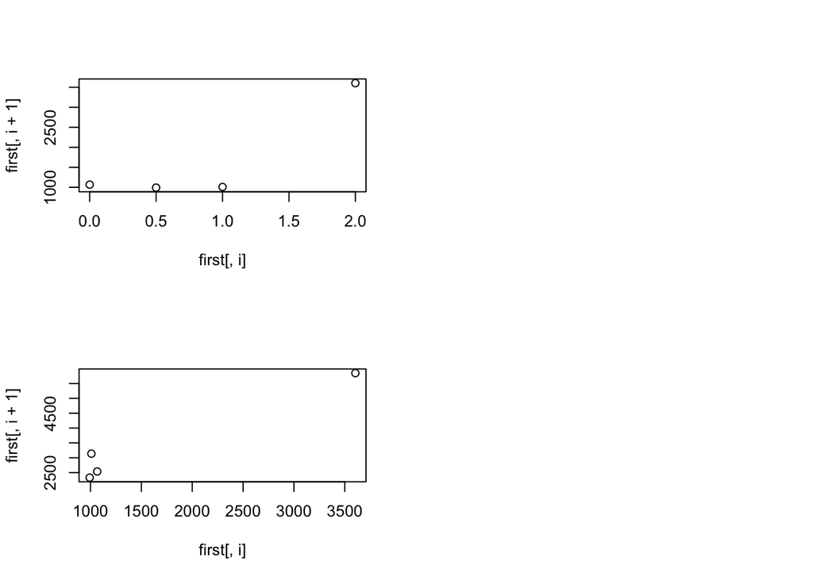

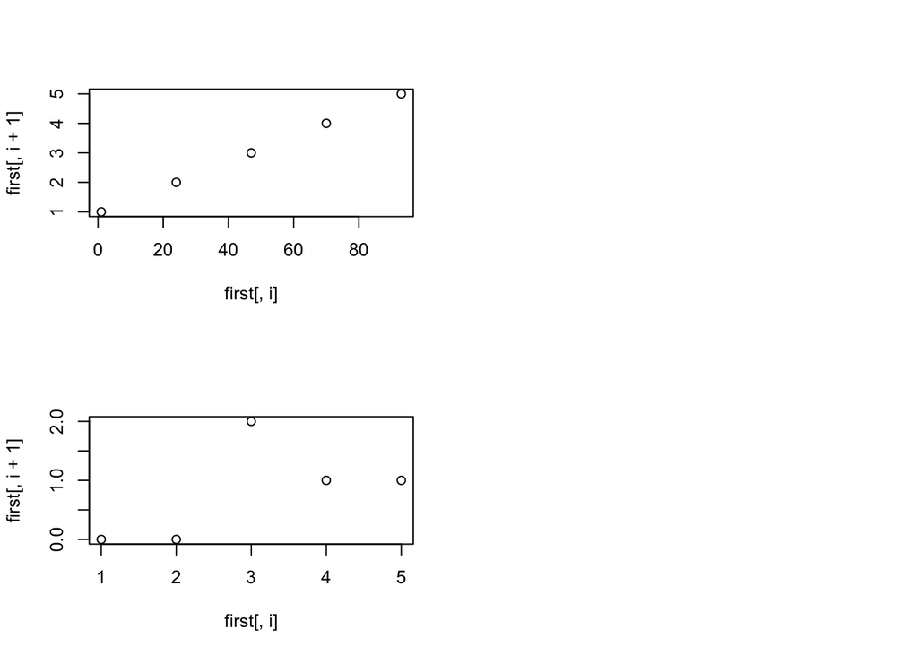

```
## [1] "example_data.csv was managed and printed to test1.csv!"
## [1] "additional_data_for_ICW.csv was managed and printed to test3.csv!"
```

```r
#As my function has three arguments, all three needs to be supplied
my_data_management(infile = "example_data.csv",
                   nskip = 5, outfile = "test1.csv")
my_data_management(infile = "additional_data_for_ICW.csv",
                   nskip = 0, outfile = "test3.csv")
```

Define a function with 2 arguments: `data.frame` and the position of a variable that should be removed from the `data.frame`. The function should remove the variable with the position in the argument subset the `data.frame` for the first observation per individual. You can assume that the variable for individuals is named `ID`. Export the created `data.frame`, with a generic the input `data.frame` name and a time stamp with the suffix .csv. A time stamp can be created using the function `Sys.time()` and `format()` and a output filename can be created using the function `paste()`.

```r
my_new_function <- function(object_name, position) {
  tmp <- get(object_name)           # retriving the object with the name object_name
  tmp <- tmp[ , -position]          # removing the variable of position=position
  tmp <- tmp[!duplicated(tmp$ID), ] # keeping only 1st obsevation/ID
  file_name <- paste0(object_name,
                      "_",
                      format(x = Sys.time(), "%d_%m_%y"),
                      ".csv")
  write.table(tmp, file = file_name, quote = FALSE,
              row.names = FALSE)
}

my_new_function("long_data", 1)
```

## 6) Installing, loading and starting packages

One of the strengths of R are the many available packages. A package is a set of function written by R-users. These have been checked by the R-core team but are maintained by the R-users who submitted the package.

There are two ways in R-studio to install packages. Install the package `dplyr` using the menu system.

Install the package `tidyr`, using the function `install.packages()`

```r
install.packages("tidyr")
```

Have a look at the internal `data.frame` cars. How many variables and observations does it have?

```r
str(cars)
## 'data.frame':    50 obs. of  2 variables:
##  $ speed: num  4 4 7 7 8 9 10 10 10 11 ...
##  $ dist : num  2 10 4 22 16 10 18 26 34 17 ...
```

`select()` is a function belonging to `dplyr`. Use the function `select()` to select the variable starting with "sp". What arguments should be used? How do you get the arguments? Does the help work?

*It cannot find the functions as it's part of the packages dplyr, which is installed but not loaded*

Load the package `dplyr` using the function `library()` and then again: use the function `select()` to select the variable starting with "sp". What happend? Does the help work? Why?

*It works now since the function is available. It's similar to the functions you wrote yourself in the above section. It needs to be compiled before it's used*

### 6.1) dplyr/tidyr

Create a `dataframe` object called `untidy` using the data example_data.csv. Use the function `gather()` from `tidyr` to change the format from wide, i.e. untidy to long, i.e. tidy, by executing the two expressions given below. Compare the results.

```r
untidy <- read.table(file = "example_data.csv", sep = ",",
                     skip = 5, na.strings = ".", header = TRUE)
too_tidy <- gather(data = untidy, key = "key", value = "value")
still_untidy <- gather(data = untidy, key = "PreviousHeaders", value = "ValueInCell",
                       -TIME, -ID.1230)

str(too_tidy)
str(still_untidy)
## 'data.frame':    110 obs. of  2 variables:
##  $ key  : chr  "TIME" "TIME" "TIME" "TIME" ...
##  $ value: num  0 0.5 1 1.5 2 4 6 8 12 24 ...
## 'data.frame':    90 obs. of  4 variables:
##  $ TIME           : num  0 0.5 1 1.5 2 4 6 8 12 24 ...
##  $ ID.1230        : int  1473 1398 2024 2154 2826 3004 3798 2854 2126 1380 ...
##  $ PreviousHeaders: chr  "ID.1221" "ID.1221" "ID.1221" "ID.1221" ...
##  $ ValueInCell    : num  1066 992 1009 NA 3604 ...
```

Create and object called `tidy`, by using the function `gather()` and set the name of the variable that will contain the header names to `ID` and the variable that will contain the values to `OBS`.

Subset the object `tidy` by keeping only the first 50 observations. Use the function `slice()` from the package `dplyr`.

Add a variable `WT` to the object `tidy` using the function `mutate()` from `dplyr`. The variable should be 70 for all observations.

Put the all commands together in one expression using the `dplyr` specific notation %>%. Export the object `tidy` to a file named **exported_tidy_data_XXXX.csv** where XXXX should be replaced by today's date. Use the functions `paste()` and `date()` to create the name.

```r
tidy <- gather(data = untidy, key = "ID", value = "OBS", -TIME)

tidy <- tidy %>%
  slice(n = 1:50) %>%
  mutate(WT = 70)

write.table(tidy, file = paste0("exported_tidy_data_", date(),".csv"),
            quote = FALSE, row.names = FALSE, sep = ",")
```

It is possible to access functions in specific packages without loading the package (i.e. using library()). The name of the package the function originates from is placed in front of the function name separated with :: like this:

```r
ggpubr::ggarrange(plot1, plot2)
```

`ggarrange()` is a function in the package `ggpubr`.

Try this option with the function `gather()` which comes from the package `tidyr`. NB! The specific notation %>% will not work without having the package loaded.

```r
tidy <- tidyr::gather(data = untidy, key = "ID", value = "OBS", -TIME)
```

# Graphics

In this In-Class Workshop, we focus on graphics in R and on visualising data and results. In this course, graphics made in base graphics and with ggplot are taught. How to represent your results graphically is out of the scope of this course.

## 1) Working with basic graphics

For the exercises in basic graphics you will use a package called ´swirl´. The R-package swirl has the slogan **Learn R, in R**, and that is indeed how to use the package.

Install the package `swirl`. (Remember how a package was installed? install.packages("swirl") )

Load `swirl`. (Remember how to load a package or library? library(swirl))

Start the learning session by typing `swirl()` in the console. Follow the instructions in the console and install the course R Programming: The basics of programming in R, then R Programming and finally Base Graphics. Go through all steps of the course in Base Graphics.

Now, create a plot like below using base graphics and the data.frame mtcars. NB! The line in the graph is a linear regression: `lm()`

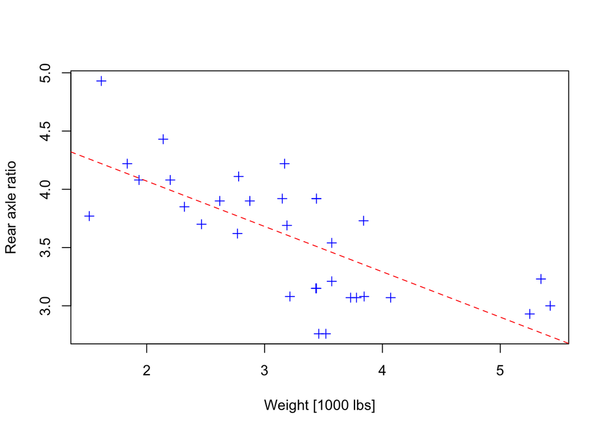

```r
plot(mtcars$wt, mtcars$drat,
     xlab = "Weight [1000 lbs]", ylab = "Rear axle ratio",
     col = "blue", pch = 3)
abline(lm(mtcars$drat ~ mtcars$wt), col = "red", lty = 2)
```

## 2) Working with ggplot

You will now perform similar graphs as you did with base graphics in swirl, but now you will use ggplot.

Install and load ggplot2 In base graphics you wrote

```r
plot(cars)
```

What happens if you write the following command?

```r
ggplot(cars)
```

You need to tell ggplot how to display the data. What happens if you use the following command?

```r
ggplot(cars) +
  geom_point()
```

Apart from how, you also need to tell ggplot what to plot. Try the following command:

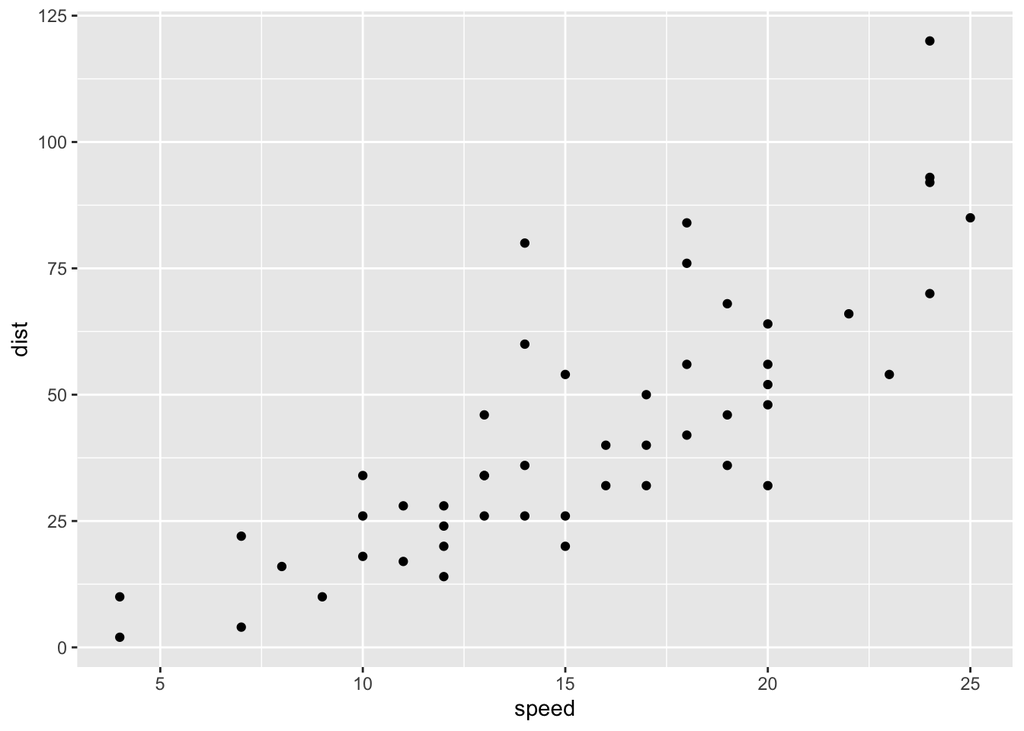

```r
ggplot(cars, aes(x = speed, y = dist)) +
  geom_point()
```

Give names ("Speed" and "Stopping distance") to the axis using the option labs.

Give a title ("My Plot") to the plot using again the option labs.

Change the colour of the points to red. Compare the two options below. What is the difference?

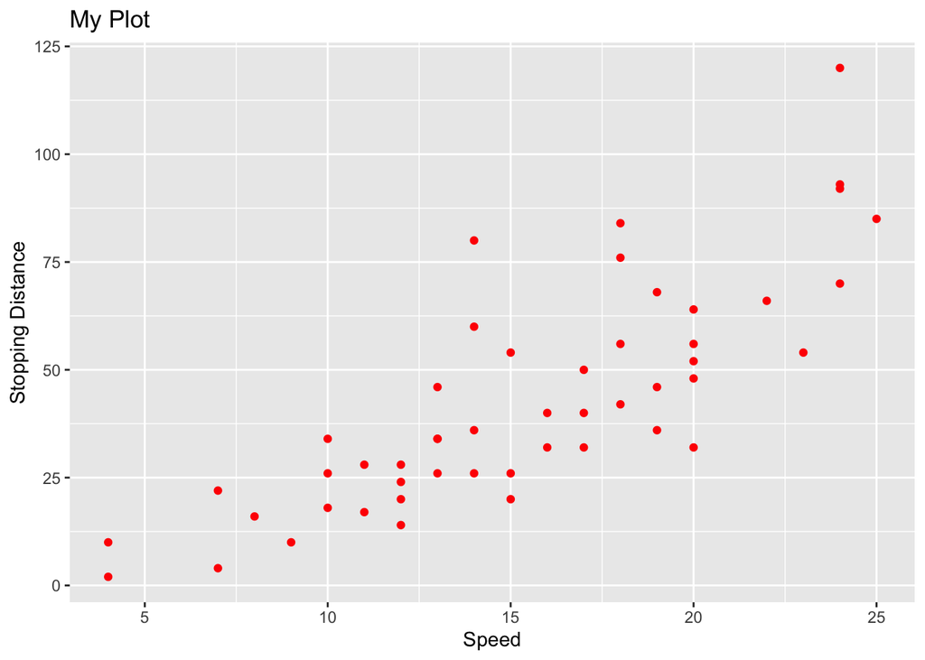

```r
ggplot(cars, aes(x = speed, y = dist)) +
  geom_point(color = "red") +
  labs(title = "My Plot", x = "Speed", y = "Stopping Distance")
```

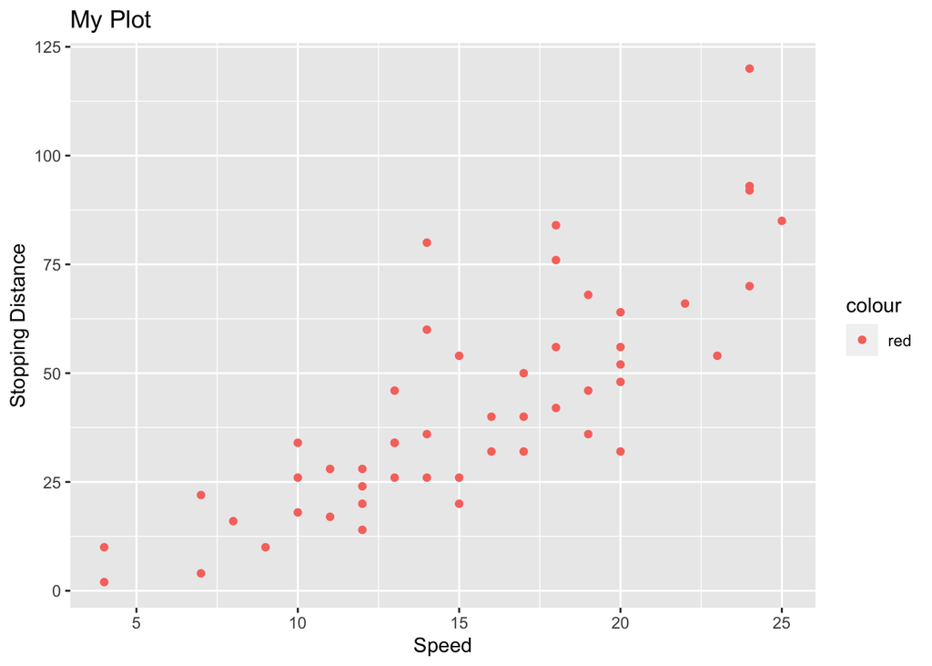

```r
ggplot(cars, aes(x = speed, y = dist)) +
  geom_point(aes(color = "red")) +
  labs(title = "My Plot", x = "Speed", y = "Stopping Distance")
```

*Red is available in the legend in one of the options*

Change the limit of the x-axis to minimum=10 and maximum=15. Compare the two options below. What is the difference? What might be the impact?

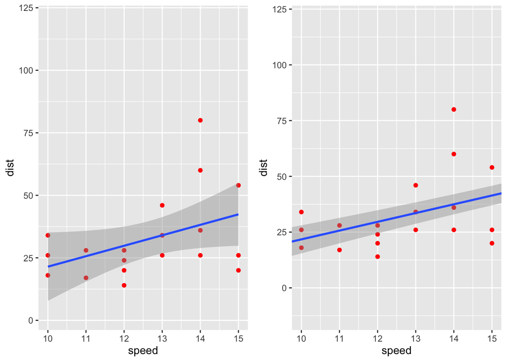

```r
plot1 <- ggplot(cars, aes(x = speed, y = dist)) +
  geom_point(color = "red") +
  xlim(10, 15) +
  geom_smooth(method = "lm")

plot2 <- ggplot(cars, aes(x = speed, y = dist)) +
  geom_point(color = "red") +
  coord_cartesian(xlim = c(10, 15)) +
  geom_smooth(method = "lm")

ggpubr::ggarrange(plot1, plot2)
## `geom_smooth()` using formula 'y ~ x'
## `geom_smooth()` using formula 'y ~ x'
```

Change the plotting symbol to triangles, using the option shape (i.e. shape = 2). Where should you place it?

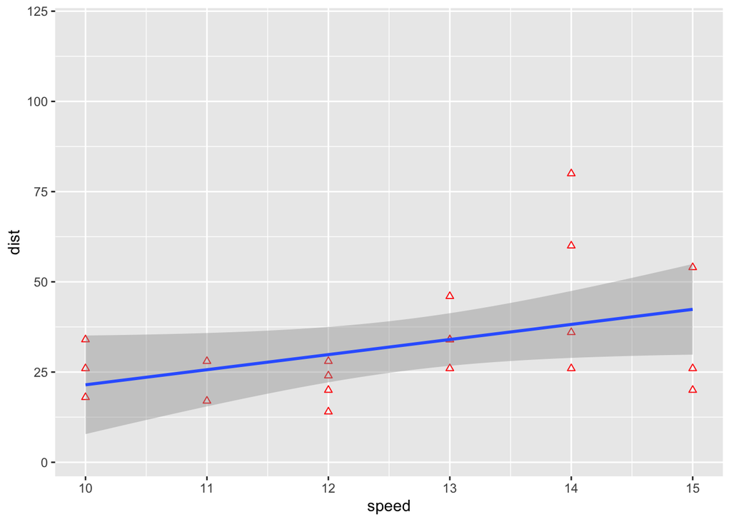

```r
ggplot(cars, aes(x = speed, y = dist)) +
  geom_point(color = "red", shape = 2) +
  xlim(10, 15) +
  geom_smooth(method = "lm")
## `geom_smooth()` using formula 'y ~ x'
```

Use ggplot to create a boxplot of variable `mpg` on the y-axis and `cyl` on the x-axis from the `data.frame mtcars`. Do you only get one box? Try categorising `cyl` (tip: use the function `as.factor`).

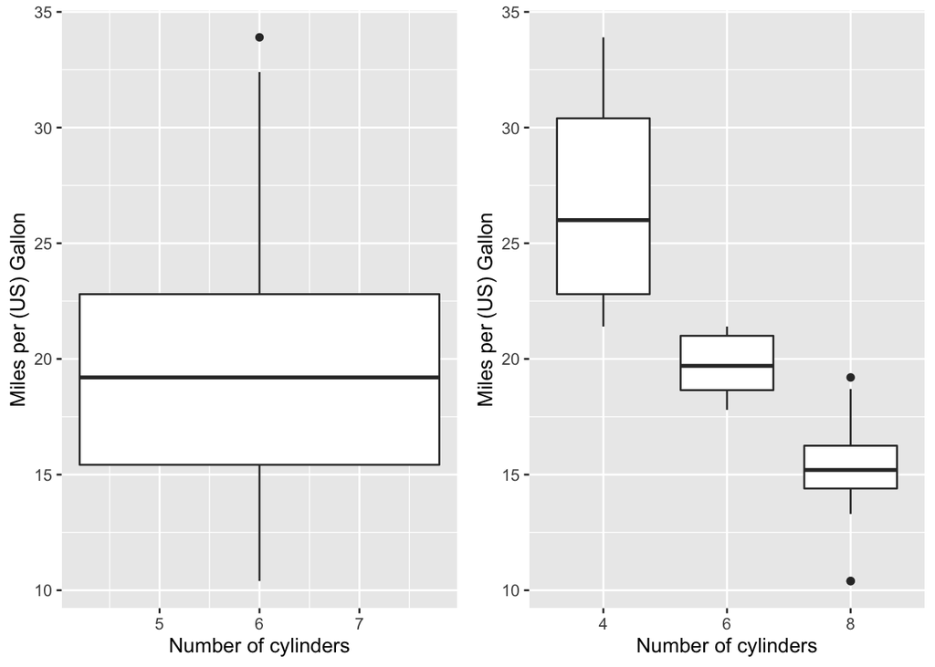

```r
plot1 <- ggplot(mtcars, aes(x = cyl, y = mpg)) +
  geom_boxplot() +
  labs(x = "Number of cylinders", y = "Miles per (US) Gallon")

plot2 <- ggplot(mtcars, aes(x = as.factor(cyl), y = mpg)) +
  geom_boxplot() +
  labs(x = "Number of cylinders", y = "Miles per (US) Gallon")

ggpubr::ggarrange(plot1, plot2)
```

*If you don't tell ggplot that your x-variable (cyl) is categorical variable, it will create a box-whiskers plot for all data (as to the left).*

Use `ggplot` to create a histogram of the variable `mpg`, with 5 bins.

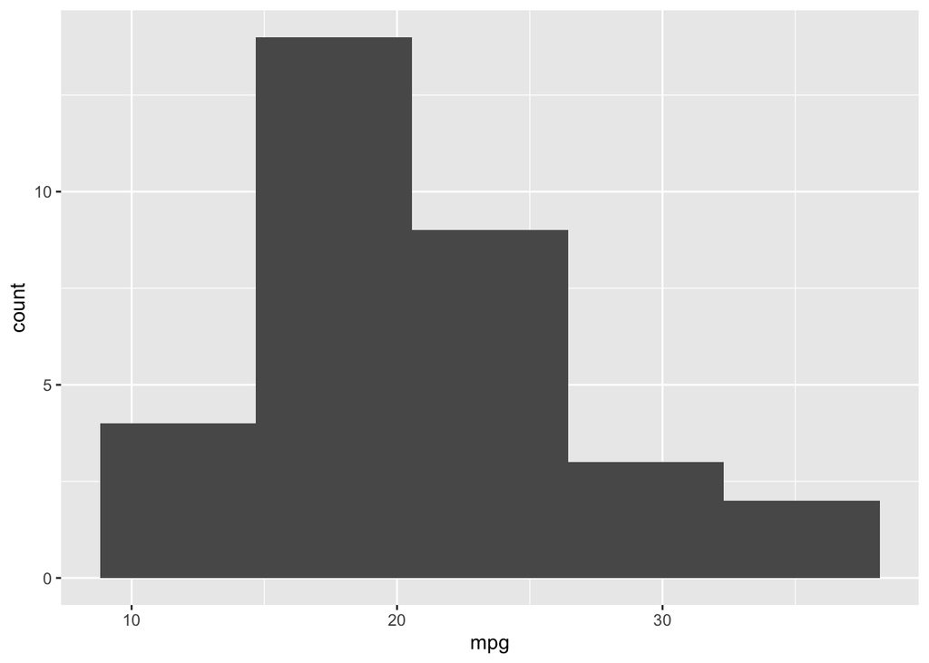

```r
ggplot(data = mtcars, aes(x = mpg)) +
  geom_histogram(bins = 5)
```

Now, create a plot like below using `ggplot` and the `data.frame mtcars`. NB! The line in the graph is a linear regression: `lm()`

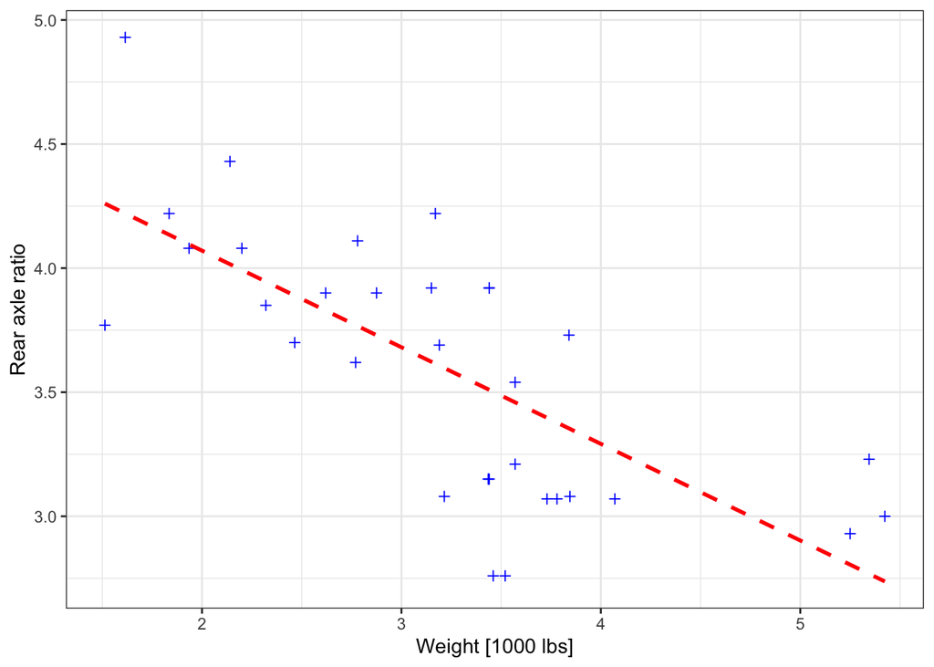

```r
ggplot(mtcars, aes(x = wt, y = drat)) +
  geom_point(shape = 3, color = "blue") +
  geom_smooth(method = lm, se = FALSE, linetype = "dashed", color = "red") +
  theme_bw() +
  labs(x = "Weight [1000 lbs]", y = "Rear axle ratio")
## `geom_smooth()` using formula 'y ~ x'
```